# SGC3_A Participants

*The purpose of this notebook is to analyze *participant-level data* collected for study SGC-3: The Insight Hypothesis*

```r
#IMPORT DATA from fall and spring files
fall_participants <- "data/fall_sgc3a_participants.csv"
spring_partcipants <- "data/spring_sgc3a_participants.csv"
df_fall <- read.csv(fall_participants)
df_spring <- read.csv(spring_partcipants)

#Create combined data frame
df_subjects <- rbind(df_fall, df_spring)
df_subjects$tri_min <- df_subjects$triangular_time / 1000 / 60
df_subjects$test_min <- df_subjects$tt_t / 1000 / 60
df_subjects$learn_min <- df_subjects$ts_t / 1000 / 60

#Create factors
df_subjects <- df_subjects %>% mutate(
  subject = as.factor(subject),
  session = as.factor(session),
  term = as.factor(term),
  condition = as.factor(condition),
  explicit = as.factor(explicit),
  impasse = as.factor(impasse),
  axis = as.factor(axis)
)

#Cleanup temporary dataframes
rm(df_fall, df_spring)
```

# INTRODUCTION

Data were collected across two terms: Fall 2017, and Spring 2018. Small changes were made to the experimental platform in Spring 2018 to change the size of multiple-choice input buttons, and to add an additional free-response question following the main task block.

TODO: Add condition images..

```r
#MANUALLY INSPECT TERMS
df_subjects %>% group_by(term) %>%
  summarize(n=n())
```

```
## # A tibble: 2 × 2
##   term         n
##   <fct>    <int>
## 1 fall17      54
## 2 spring18    72
```

SGC3-A is a 2-condition (111-control VS 121-impasse) between-subjects experiment with 126 participants.

```r
#The data collection framework was designed such that  that stimuli the participant experienced were triggered based on the input of a particular 'condition code' by the participant. This allowed us to collect data for a number of studies simultaneously in the same data collection session (i.e. multiple students in the computer lab at the same time).  Thus, the **final_participants.json** file contains data for a number of studies, identified by parsing the **condition** variable.

#First Digit    | explicit scaffolding
# ------------- |-------------
# 1      | control (no-scaffold)
# 2      | text/image (static)
# 3      | interactive
#
#Second Digit    | implicit scaffolding
# ------------- |-------------
#1      | control (no-scaffold)
#2      | impasse (no orthogonal answer)
#
#Third Digit    | grid format
#------------- |-------------
#1 | full orthogonal
#2 | partial orthogonal
#3 | diagonal

#MANUALLY INSPECT conditions
df_subjects %>% group_by(condition) %>%
  summarize(n=n())
```

```
## # A tibble: 2 × 2
##   condition     n
##   <fct>     <int>
## 1 111          62
## 2 121          64
```

# DESCRIPTIVES

## Participant Demographics

```r
#Describe participants
favstats(~age, data = df_subjects)
```

```
##  min Q1 median Q3 max     mean       sd   n missing
##   18 19     20 21  33 20.36508 2.122652 126       0
```

126 participants (60 % female ) undergraduate STEM majors at a public American University participated in exchange for course credit (age: 18 - 33 years). Participants were randomly assigned to one of two experimental groups.

## Response Accuracy

Response accuracy refers to how many questions the subject answers with a correct-triangular interpretation.

```r
#DESCRIBE distribution of triangular-correct scores
score.stats <- favstats(df_subjects$triangular_score)
score.stats
```

```
##  min Q1 median Q3 max     mean       sd   n missing
##    1  2      3 11  15 5.809524 4.893611 126       0
```

```r
stat.desc(df_subjects$triangular_score)
```

```
##      nbr.val     nbr.null       nbr.na          min          max        range
##  126.0000000    0.0000000    0.0000000    1.0000000   15.0000000   14.0000000
##          sum       median         mean      SE.mean CI.mean.0.95          var
##  732.0000000    3.0000000    5.8095238    0.4359575    0.8628140   23.9474286
##      std.dev     coef.var
##    4.8936110    0.8423429
```

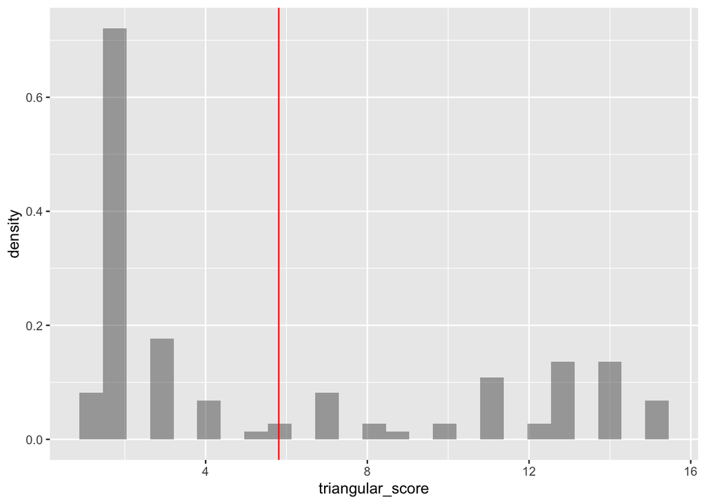

```r
#VISUALIZE distribution of response accuracy
gf_dhistogram(~triangular_score, data = df_subjects) %>%
  gf_vline(xintercept = score.stats$mean, color = "red")
```

Accuracy scores (n = 126) range from 1 to 15 with a mean score of (M = 5.81, SD = 4.89).

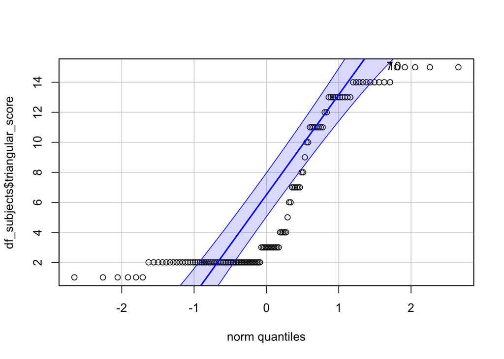

```r
qqPlot(df_subjects$triangular_score)
```

TODO: These data are CLEARLY not normal. What to do?.

## Response Latency

TODO: Investigate super high and super low response times.. TODO: Investigate appropriate models for response time data. (see: https://lindeloev.github.io/shiny-rt/) .

```r
#DESCRIBE distribution of triangular-correct scores
time.stats <- favstats(df_subjects$tri_min)
time.stats # stat.desc(df_subjects$tri_min)
```

```
##     min       Q1   median       Q3      max    mean       sd   n missing
##  3.7708 7.283617 8.804333 10.71089 19.98955 9.25302 2.902315 126       0
```

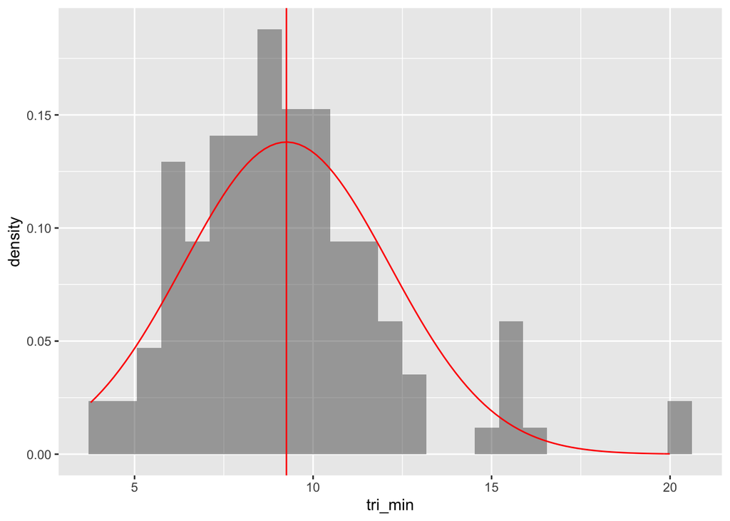

```r
#VISUALIZE distribution of response accuracy
gf_dhistogram(~tri_min, data = df_subjects) %>%
  gf_vline(xintercept = time.stats$mean, color = "red") %>%
  gf_fitdistr(color="red") # gf_dist("norm", color="red", params=list(time.stats$mean, time.stats$sd))
```

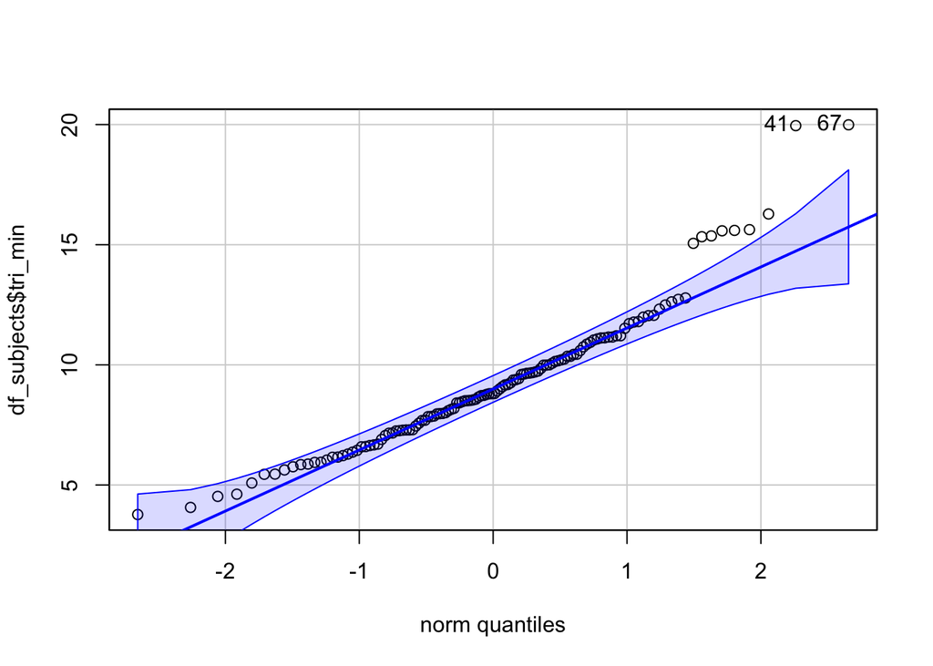

```
## [1] 67 41
```

```r
qqPlot(df_subjects$tri_min)
```

However, the distribution is clearly not normal, so it is appropriate to transform the response latency variable.

### TRANSFORM Response Latency

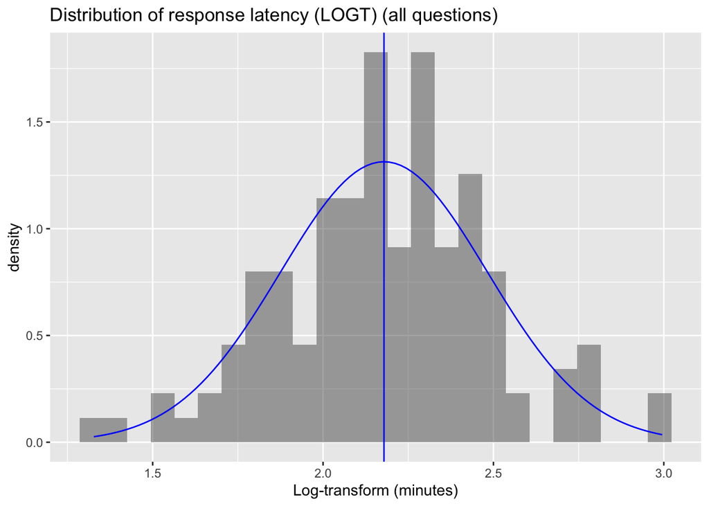

```r
#APPLY a log transform
df_subjects$log_time <- log(df_subjects$tri_min)
log_time.stats <- favstats(~log_time, data = df_subjects)
log_time.stats

gf_dhistogram(~log_time, data = df_subjects) %>%
gf_vline(xintercept = ~log_time.stats$mean, color = "blue") %>%
gf_fitdistr(color="blue") %>%
gf_labs(title ="Distribution of response latency (LOGT) (all questions)", x="Log-transform (minutes)")
```

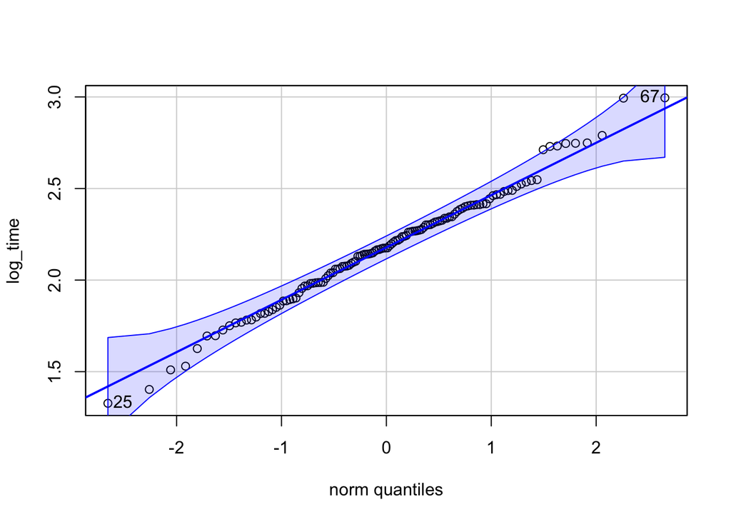

```r
#VERIFY normality of resulting data with qqPlot
qqPlot(~log_time, data = df_subjects)
```

# HYPOTHESIS TESTING

## Response Accuracy by Condition

The experimental hypothesis (H1) is that structuring the data to pose an impasse (condition 121) will produce significantly better performance than non-impasse (condition 111). The null hypothesis (H0) is that there will be no difference in performance between conditions. A linear model predicting triangular_score from condition indicates a statistically significant difference between conditions, explaning 7% of the model variance.

### [EXPLORE]

```r
#DESCRIBE scores by condition
score.cond.stats <- favstats(triangular_score ~ condition, data = df_subjects)
score.cond.stats
```

```
##   condition min Q1 median    Q3 max     mean       sd  n missing
## 1       111   1  2    2.0  3.75  15 4.500000 4.643875 62       0
## 2       121   1  2    6.5 12.00  15 7.078125 4.828174 64       0
```

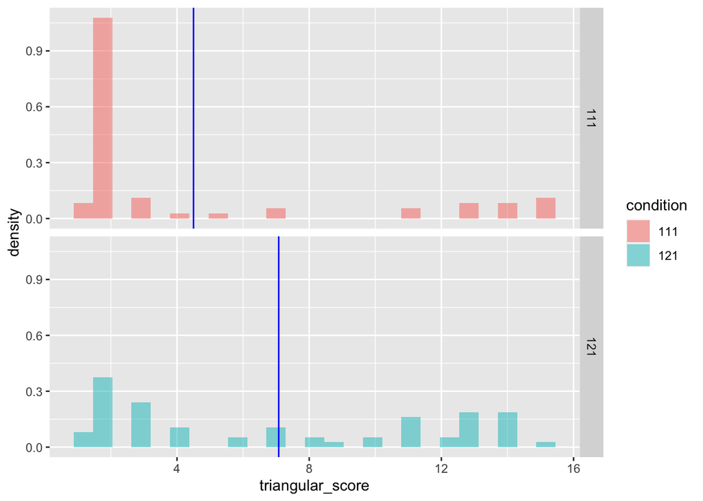

```r
#VISUALIZE scores by condition
gf_dhistogram( ~triangular_score, fill= ~condition, data = df_subjects) %>%
  gf_facet_grid(condition~.) %>%
  gf_vline(xintercept = ~mean, data = score.cond.stats, color = "blue")
```

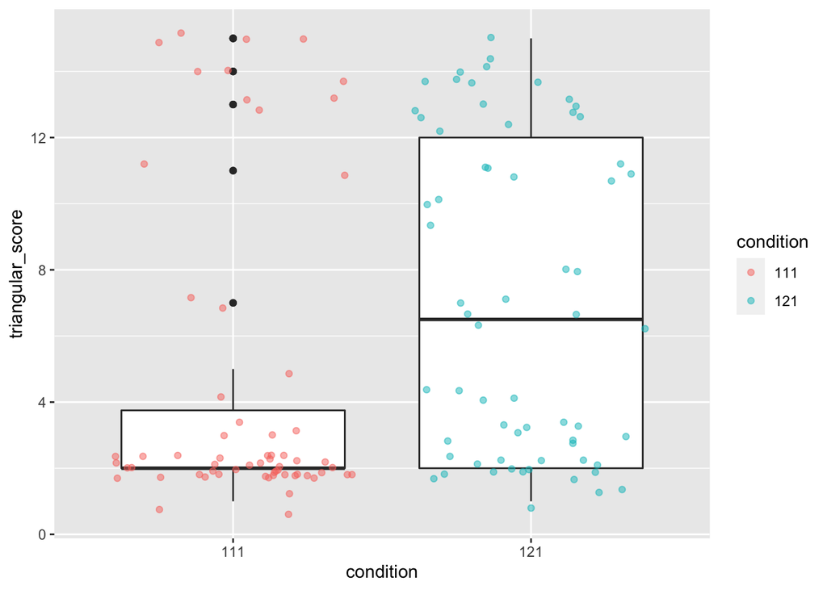

```r
#VISUALIZE scores by condition
gf_boxplot(triangular_score ~ condition, data=df_subjects) %>%
  gf_jitter(color=~condition, alpha=0.5)
```

Accuracy scores (n = 126) range from 1 to 15 with a mean score of (M = 5.81, SD = 4.89). On average, participants in the impasse group had higher scores (M = 7.08 SD = 4.83) than those in #the non-impasse control group (M = 4.5, SD = 4.64)**

### [MODEL]

```r
#MODEL triangular score by condition with a linear model
m1 = lm(triangular_score ~ condition, data = df_subjects)
summary(m1)
```

```
##
## Call:
## lm(formula = triangular_score ~ condition, data = df_subjects)
##
## Residuals:
##    Min     1Q Median     3Q    Max
## -6.078 -3.078 -2.500  3.922 10.500
##
## Coefficients:
##              Estimate Std. Error t value Pr(>|t|)
## (Intercept)    4.5000     0.6018   7.478  1.2e-11 ***
## condition121   2.5781     0.8444   3.053  0.00277 **
## ---
## Signif. codes:  0 '***' 0.001 '**' 0.01 '*' 0.05 '.' 0.1 ' ' 1
##
## Residual standard error: 4.738 on 124 degrees of freedom
## Multiple R-squared:  0.06993,    Adjusted R-squared:  0.06243
## F-statistic: 9.323 on 1 and 124 DF,  p-value: 0.00277
```

```r
#the first co-efficient represents the model estimate for the first group, the second, the difference for the second group

# partition variance with anova
# anova(m1)
# supernova(m1) #runs but doesn't knit?

#calculate effect size
eta_squared(m1, partial = FALSE)
```

```
## # Effect Size for ANOVA (Type I)
##
## Parameter | Eta2 |       95% CI
## -------------------------------
## condition | 0.07 | [0.01, 1.00]
##
## - One-sided CIs: upper bound fixed at (1).
```

A linear model predicting triangular score accuracy by condition explains approximately 7% of the variance in triangular score F(1,124) = 9.32, p < 0.05)

# POST-HOC EXPLORATION

## 1. Response Accuracy

## 1.1 Learning VS Testing

In SGC3A, participants are provided with 15 questions. For the first 5 questions, they experience a ‘scaffolded’ version the stimuli (control condition = 111, impasse scaffold = 121).

What if we **only** consider the final 10 test items? Assume students have 5 questions worth of scaffolding to figure out the graph for themselves, and we only assess accuracy for the final ten items? Is our experimental hypothesis supported?

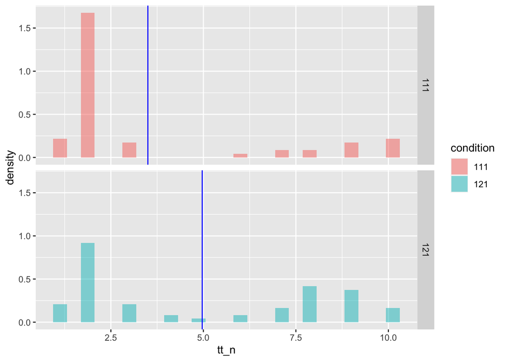

```r
#DESCRIBE scores by condition
test.stats <- favstats(tt_n ~ condition, data = df_subjects)

#VISUALIZE scores by condition
gf_dhistogram( ~tt_n, fill= ~condition, data = df_subjects) %>%
  gf_facet_grid(condition~.) %>%
  gf_vline(xintercept = ~mean, data = test.stats, color = "blue")
```

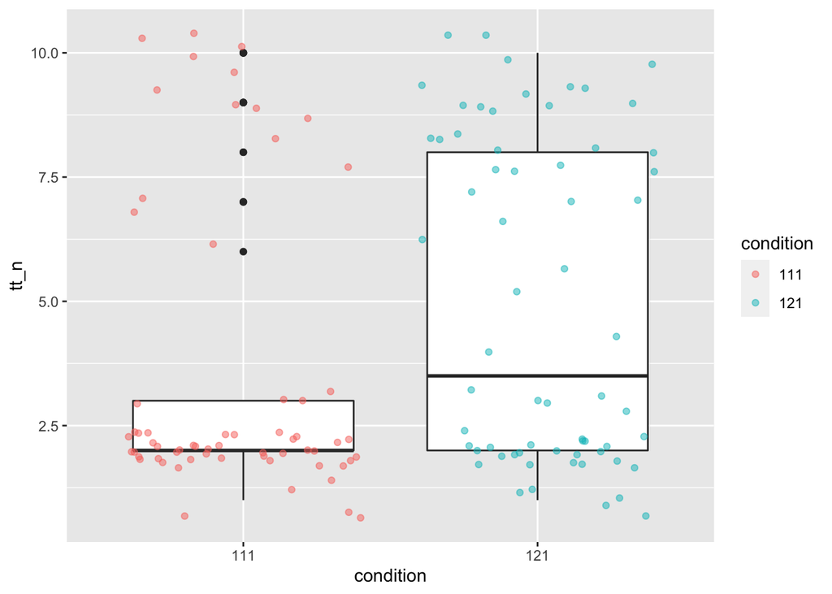

```r
#VISUALIZE scores by condition
gf_boxplot(tt_n ~ condition, data=df_subjects) %>%
  gf_jitter(color=~condition, alpha=0.5)
```

```r
mTest = lm(tt_n ~ condition, data = df_subjects)
summary(mTest)
```

```
##
## Call:
## lm(formula = tt_n ~ condition, data = df_subjects)
##
## Residuals:
##    Min     1Q Median     3Q    Max
## -3.969 -2.367 -1.500  3.031  6.500
##
## Coefficients:
##              Estimate Std. Error t value Pr(>|t|)
## (Intercept)    3.5000     0.3910   8.951 4.28e-15 ***
## condition121   1.4687     0.5486   2.677  0.00843 **
## ---
## Signif. codes:  0 '***' 0.001 '**' 0.01 '*' 0.05 '.' 0.1 ' ' 1
##
## Residual standard error: 3.079 on 124 degrees of freedom
## Multiple R-squared:  0.05464,    Adjusted R-squared:  0.04701
## F-statistic: 7.167 on 1 and 124 DF,  p-value: 0.008432
```

```r
anova(mTest)
```

```
## Analysis of Variance Table
##
## Response: tt_n
##            Df  Sum Sq Mean Sq F value   Pr(>F)
## condition   1   67.94  67.936  7.1667 0.008432 **
## Residuals 124 1175.44   9.479
## ---
## Signif. codes:  0 '***' 0.001 '**' 0.01 '*' 0.05 '.' 0.1 ' ' 1
```

```r
# supernova(mTest)
```

A linear regression model predicting score (test blocks only) from condition explained 5% of variance, F(1,124) = 7.17, p < 0.05.

## 2. Response Latency

### 2.1 Response Latency vs. Accuracy

Are response time (on the triangular blocks (test and learn)) and response accuracy correlated?

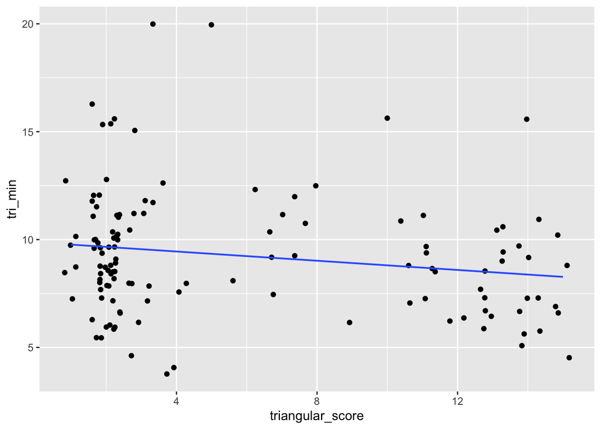

```r
#VISUALIZE relationship between response time and accuracy
gf_jitter(tri_min ~ triangular_score, data = df_subjects) %>%
  gf_lm()
```

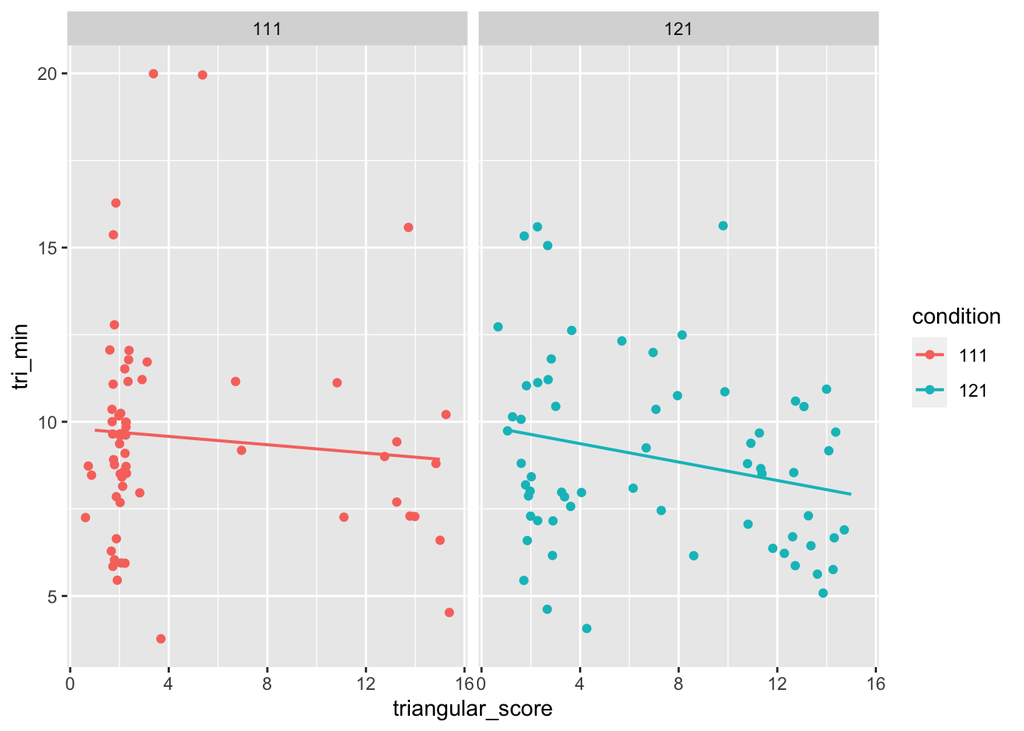

```r
#VISUALIZE relationship between response time and accuracy by condition
gf_jitter(tri_min ~ triangular_score, color = ~condition, data = df_subjects) %>%
  gf_facet_grid(~condition) %>%
  gf_lm()
```

From visual inspection, it does not *appear* that score and time and strongly correlated.

```r
#simple linear model predicting triangular score from triangular time
m1 = lm(triangular_score ~ tri_min, data = df_subjects)

summary(m1, correlation=TRUE)
```

```
##
## Call:
## lm(formula = triangular_score ~ tri_min, data = df_subjects)
##
## Residuals:
##    Min     1Q Median     3Q    Max
## -5.417 -3.899 -2.593  5.042 10.111
##
## Coefficients:
##             Estimate Std. Error t value Pr(>|t|)
## (Intercept)   8.6188     1.4439   5.969 2.33e-08 ***
## tri_min      -0.3036     0.1489  -2.038   0.0436 *
## ---
## Signif. codes:  0 '***' 0.001 '**' 0.01 '*' 0.05 '.' 0.1 ' ' 1
##
## Residual standard error: 4.833 on 124 degrees of freedom
## Multiple R-squared:  0.03242,    Adjusted R-squared:  0.02462
## F-statistic: 4.155 on 1 and 124 DF,  p-value: 0.04364
##
## Correlation of Coefficients:
##         (Intercept)
## tri_min -0.95
```

```r
cor.test(df_subjects$triangular_score, df_subjects$tri_min)
```

```
##
##  Pearson's product-moment correlation
##
## data:  x and y
## t = -2.0384, df = 124, p-value = 0.04364
## alternative hypothesis: true correlation is not equal to 0
## 95 percent confidence interval:
##  -0.344131528 -0.005323502
## sample estimates:
##        cor
## -0.1800628
```

However, a simple linear regression indicates a significant (though small) negative correlation between score accuracy and response time r = -0.18, t(124) = -2.04, p < 0.05.

### 2.2 Response Latency by Condition

Do response times differ by condition?

```r
time.stats <- favstats(tri_min ~ condition, data = df_subjects)
time.stats
```

```
##   condition      min       Q1   median       Q3      max     mean       sd  n
## 1       111 3.770800 7.734442 9.137217 10.89818 19.98955 9.549685 3.094600 62
## 2       121 4.067033 7.018921 8.525967 10.63243 15.62718 8.965625 2.696314 64
##   missing
## 1       0
## 2       0
```

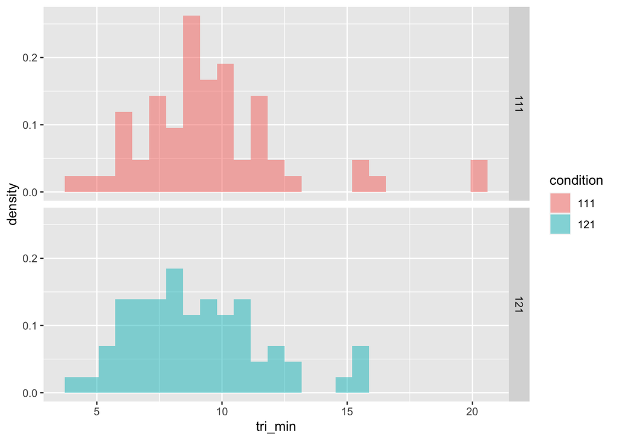

```r
gf_dhistogram(~tri_min, fill = ~condition, data = df_subjects) %>%
  gf_facet_grid(condition~.)
```

```r
m1 <- lm(tri_min ~ condition, data = df_subjects)
summary(m1)
```

```
##
## Call:
## lm(formula = tri_min ~ condition, data = df_subjects)
##
## Residuals:
##     Min      1Q  Median      3Q     Max
## -5.7789 -1.8640 -0.4397  1.5596 10.4399
##
## Coefficients:
##              Estimate Std. Error t value Pr(>|t|)
## (Intercept)    9.5497     0.3682  25.937   <2e-16 ***
## condition121  -0.5841     0.5166  -1.131     0.26
## ---
## Signif. codes:  0 '***' 0.001 '**' 0.01 '*' 0.05 '.' 0.1 ' ' 1
##
## Residual standard error: 2.899 on 124 degrees of freedom
## Multiple R-squared:  0.0102, Adjusted R-squared:  0.00222
## F-statistic: 1.278 on 1 and 124 DF,  p-value: 0.2604
```

The difference in average response time is not statistically significant F(1,124) = 1.28 , p > 0.05, with a linear model predicting response time from condition explaining only 1% of variance. ### 2.3 Is Response Latency predictive?

Does adding response time to the model help predict score accuracy?

```r
#simple  model predicting triangular score from triangular time
m1 = lm(triangular_score ~ condition, data = df_subjects)
m2 = lm(triangular_score ~ condition + tri_min, data = df_subjects)
summary(m1)
```

```
##
## Call:
## lm(formula = triangular_score ~ condition, data = df_subjects)
##
## Residuals:
##    Min     1Q Median     3Q    Max
## -6.078 -3.078 -2.500  3.922 10.500
##
## Coefficients:
##              Estimate Std. Error t value Pr(>|t|)
## (Intercept)    4.5000     0.6018   7.478  1.2e-11 ***
## condition121   2.5781     0.8444   3.053  0.00277 **
## ---
## Signif. codes:  0 '***' 0.001 '**' 0.01 '*' 0.05 '.' 0.1 ' ' 1
##
## Residual standard error: 4.738 on 124 degrees of freedom
## Multiple R-squared:  0.06993,    Adjusted R-squared:  0.06243
## F-statistic: 9.323 on 1 and 124 DF,  p-value: 0.00277
```

```r
summary(m2)
```

```
##
## Call:
## lm(formula = triangular_score ~ condition + tri_min, data = df_subjects)
##
## Residuals:
##    Min     1Q Median     3Q    Max
## -5.998 -3.417 -2.112  3.993 11.075
##
## Coefficients:
##              Estimate Std. Error t value Pr(>|t|)
## (Intercept)    6.9947     1.5119   4.626 9.28e-06 ***
## condition121   2.4255     0.8412   2.883  0.00464 **
## tri_min       -0.2612     0.1455  -1.796  0.07500 .
## ---
## Signif. codes:  0 '***' 0.001 '**' 0.01 '*' 0.05 '.' 0.1 ' ' 1
##
## Residual standard error: 4.696 on 123 degrees of freedom
## Multiple R-squared:  0.09369,    Adjusted R-squared:  0.07895
## F-statistic: 6.357 on 2 and 123 DF,  p-value: 0.002359
```

```r
anova(m1) # supernova(m1)
```

```
## Analysis of Variance Table
##
## Response: triangular_score
##            Df  Sum Sq Mean Sq F value  Pr(>F)
## condition   1  209.32 209.319  9.3228 0.00277 **
## Residuals 124 2784.11  22.452
## ---
## Signif. codes:  0 '***' 0.001 '**' 0.01 '*' 0.05 '.' 0.1 ' ' 1
```

```r
anova(m2) # supernova(m2)
```

```
## Analysis of Variance Table
##
## Response: triangular_score
##            Df  Sum Sq Mean Sq F value   Pr(>F)
## condition   1  209.32 209.319  9.4900 0.002549 **
## tri_min     1   71.12  71.122  3.2245 0.074999 .
## Residuals 123 2712.99  22.057
## ---
## Signif. codes:  0 '***' 0.001 '**' 0.01 '*' 0.05 '.' 0.1 ' ' 1
```

TODO: What is the appropriate inference to draw from this model comparison?.

### 2.4 Response Latency on Learn (v) Test

```r
#DESCRIBE distribution of learning block times scores
learn.time.stats <- favstats(df_subjects$learn_min)
learn.time.stats
```

```
##       min       Q1   median       Q3      max     mean       sd   n missing
##  1.235167 2.659575 3.713108 4.919796 11.10467 4.030636 1.878286 126       0
```

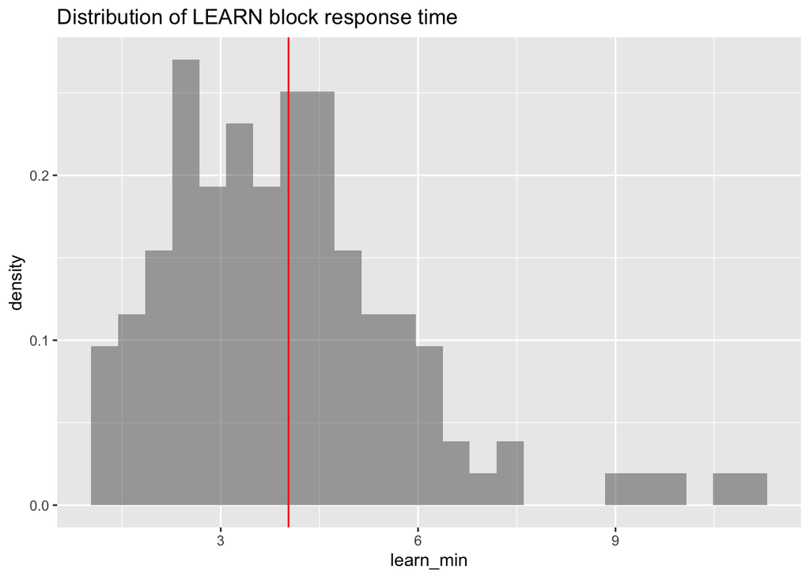

```r
#VISUALIZE distribution of learning block time
gf_dhistogram(~learn_min, data = df_subjects) %>%
  gf_vline(xintercept = mean(df_subjects$learn_min), color = "red") %>%
  gf_labs(title = "Distribution of LEARN block response time ")
```

Total learning block times ranged from 1.24 min to 11.1, with M = 4.03, SD = 1.88.

```r
#DESCRIBE distribution of learning block times scores
test.time.stats <- favstats(df_subjects$test_min)
test.time.stats
```

```
##       min       Q1   median       Q3      max     mean       sd   n missing
##  2.369883 3.969679 5.141117 6.089417 14.53573 5.222384 1.653947 126       0
```

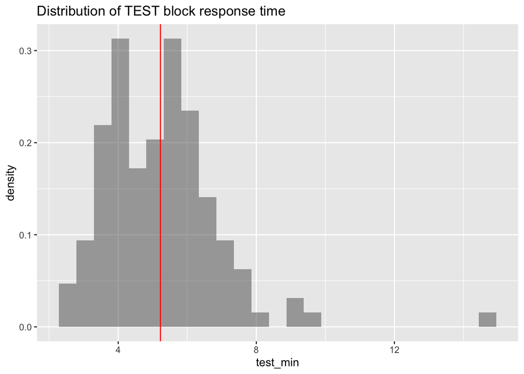

```r
#VISUALIZE distribution of learning block time
gf_dhistogram(~test_min, data = df_subjects) %>%
  gf_vline(xintercept = mean(df_subjects$test_min), color = "red") %>%
  gf_labs(title = "Distribution of TEST block response time ")
```

Total testing block times ranged from 2.37 min to 14.54, with M = 5.22, SD = 1.65.

Is time spent on learning (v) testing blocks correlated?

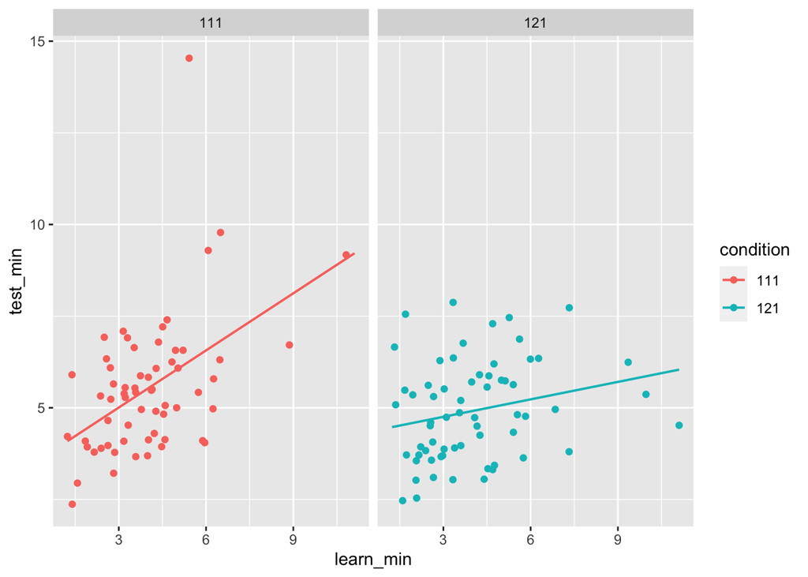

```r
#VISUALIZE test v learning block time
gf_point(test_min ~ learn_min, color = ~condition, data = df_subjects) %>%
  gf_facet_grid(~condition) %>%
  gf_lm()
```

```r
m1 <- lm( test_min ~ learn_min , data = df_subjects)
summary(m1)
```

```
##
## Call:
## lm(formula = test_min ~ learn_min, data = df_subjects)
##
## Residuals:
##     Min      1Q  Median      3Q     Max
## -2.8653 -1.0600 -0.1611  0.7657  8.8886
##
## Coefficients:
##             Estimate Std. Error t value Pr(>|t|)
## (Intercept)  3.98854    0.32947  12.106  < 2e-16 ***
## learn_min    0.30612    0.07414   4.129 6.65e-05 ***
## ---
## Signif. codes:  0 '***' 0.001 '**' 0.01 '*' 0.05 '.' 0.1 ' ' 1
##
## Residual standard error: 1.557 on 124 degrees of freedom
## Multiple R-squared:  0.1209, Adjusted R-squared:  0.1138
## F-statistic: 17.05 on 1 and 124 DF,  p-value: 6.65e-05
```

```r
anova(m1) #supernova(m1)
```

```
## Analysis of Variance Table
##
## Response: test_min
##            Df  Sum Sq Mean Sq F value   Pr(>F)
## learn_min   1  41.325  41.325  17.046 6.65e-05 ***
## Residuals 124 300.618   2.424
## ---
## Signif. codes:  0 '***' 0.001 '**' 0.01 '*' 0.05 '.' 0.1 ' ' 1
```

```r
cor.test(df_subjects$test_min, df_subjects$learn_min)
```

```
##
##  Pearson's product-moment correlation
##
## data:  x and y
## t = 4.1286, df = 124, p-value = 6.65e-05
## alternative hypothesis: true correlation is not equal to 0
## 95 percent confidence interval:
##  0.1839139 0.4925932
## sample estimates:
##       cor
## 0.3476381
```

A linear model predicting test block time from learning block time reveals that learning block time explains 12% variance in testing block time (F(1,124) = 17.1, p < 0.001), with an 18s increase in testing time for every 1 minute increase in learning time. The two variables have a small, significant correlation r = 0.35, t(124) = 4.13, p < 0.001, 95% CI [0.18, 0.49].

# DUE DILLIGENCE

## 1. Power Analysis

What is the appropriate sample size to detect a moderate-sized effect (f = 0.25) at a 0.05 alpha level?

```r
#K = 2 groups, f = 0.25 is moderate effect size
pwr.anova.test(k=2,f=0.25 ,sig.level=.05, power=.8)
```

```
##
##      Balanced one-way analysis of variance power calculation
##
##               k = 2
##               n = 63.76561
##               f = 0.25
##       sig.level = 0.05
##           power = 0.8
##
## NOTE: n is number in each group
```

## 2. TERM-LEVEL analysis

Data from the first term only (Fall 2017) were analyzed and presented as a paper at CogSci 2019, in support of the experimental hypothesis (H1: impasse is an effective scaffold). Combined across terms, the prior analyses ALSO support the experimental hypothesis. Do the spring-only data also support the H1 hypothesis?

```r
#simple linear model predicting triangle score from condition for spring data only
mspring = lm(triangular_score ~ condition, data = df_subjects %>% filter(term=='spring18'))

#partition variance
anova(mspring)# supernova(m2)
```

```
## Analysis of Variance Table
##
## Response: triangular_score
##           Df Sum Sq Mean Sq F value Pr(>F)
## condition  1   55.7  55.704  2.3986 0.1259
## Residuals 70 1625.6  23.223
```

```r
confint(mspring)
```

```
##                   2.5 %   97.5 %
## (Intercept)   3.3182580 6.567456
## condition121 -0.5064242 4.026115
```

## 3. Combining Fall and Spring

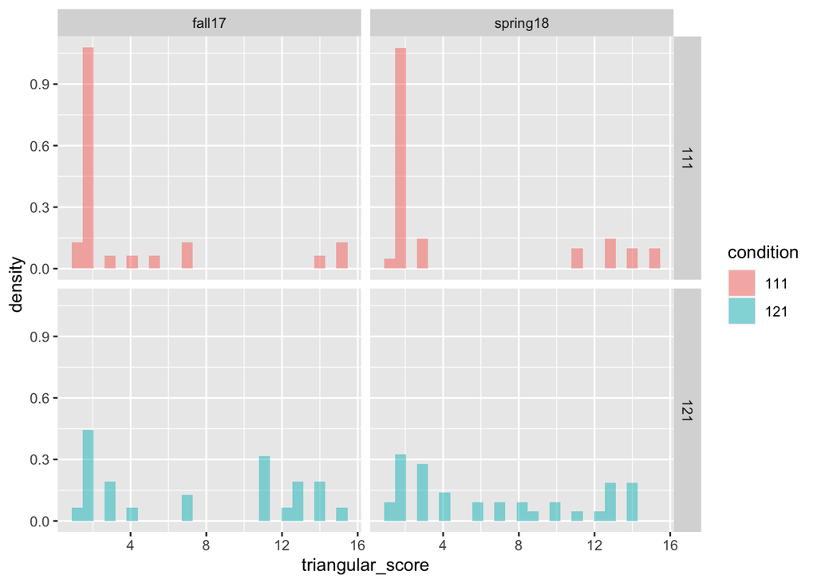

```r
#VISUALIZE scores by condition
gf_dhistogram( ~triangular_score, fill= ~condition, data = df_subjects) %>%
  gf_facet_grid(condition~term)
```

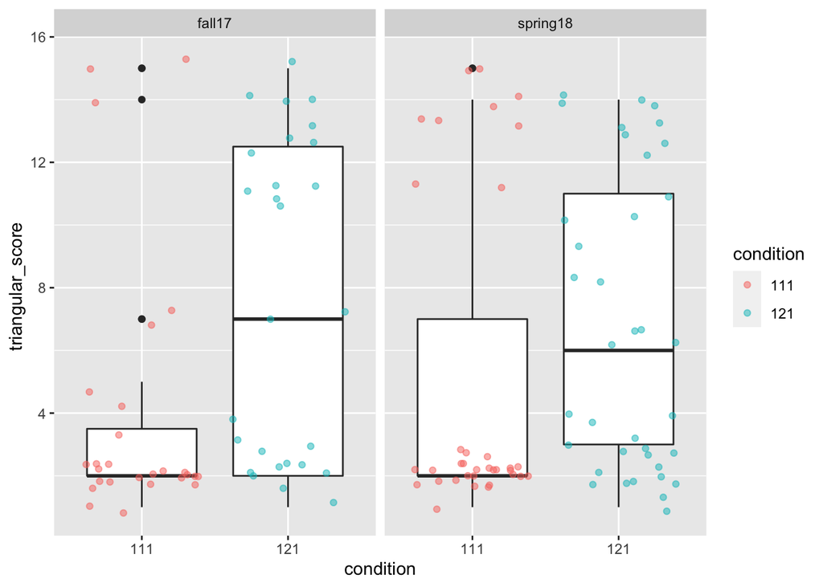

```r
#
# #VISUALIZE scores by condition
gf_boxplot(triangular_score ~ condition, data=df_subjects) %>%
  gf_facet_grid(~term) %>%
  gf_jitter(color=~condition, alpha=0.5)
```

By visual inspection, the distribution of accuracy scores across condition appear similiar across terms.

**It is therefore reasonable to conclude that data collected in Spring 2018 can be combined with Fall 2017.**